# 教学文档 2：RAND/UCLA 适宜性评价全流程

Ming Yang

2026-10-10

# 1. 为什么这不是普通 Delphi

Delphi 的核心逻辑是：匿名反复评分 → 反馈 → 再评分 → 意见逐渐收敛。它适合共识条目、指标选择、优先级、核心结局和定义。

**RAND/UCLA Appropriateness Method（RAM）** 要回答的是另一个问题：

> 某临床措施在特定场景下是否“适宜”？

适宜指：对普通患者、由普通医生在普通机构实施时，**预期获益超过预期伤害的程度**（通常不考虑成本）。Fitch 等（2001）手册是本教程的方法学依据。

关键差别：

|  | 医学共识 Delphi | RAND/UCLA |
| --- | --- | --- |
| 目标 | 条目是否纳入共识 | 指征是否适宜 / 不确定 / 不适宜 |
| 面板 | 常 30–80+ 人 | 经典 9 人左右（约 7–15） |
| 分歧 | 用 IQR、赞同率 | 经典两端规则 + IPRAS / DI |
| 会议 | 讨论临界条目 | 第 1 轮后正式讨论，再独立复评 |
| 强迫一致 | 仍常被误用 | **明确不强迫共识** |

样本数据 `rand_ucla_demo`：9 名多学科专家、24 个血运重建指征、两轮 1–9 分。

```r
library(delphir)
data("rand_ucla_demo", package = "delphir")
rand_ucla_demo
```

```
#> Delphi 研究
#>   题目: 稳定型冠心病血运重建适宜性评价（模拟 RAND/UCLA 面板）
#>   场景: RAND/UCLA 适宜性评价
#>   专家: 9 人；条目: 24；轮次: 1, 2
#>   评分行数: 408
```

```r
unlist(rand_ucla_demo$meta)
```

```
#>                                                          title
#>        "稳定型冠心病血运重建适宜性评价（模拟 RAND/UCLA 面板）"
#>                                                      objective
#> "判断特定临床指征下血运重建是否适宜，而不是强迫形成单一共识。"
#>                                                          users
#>                                         "心血管专科与全科医师"
#>                                                      geography
#>                                         "教学示例，非真实指南"
#>                                                  evidence_note
#>                        "模拟证据综述已在第 1 轮前提供给面板。"
#>                                                      anonymity
#>         "第 1 轮独立匿名评分；第 2 轮会间讨论后再次独立评分。"
#>                                                         ethics
#>                                               "教学模拟数据。"
```

# 2. 流程概览（按手册）

1. 选主题，做文献综述并形成**指征清单**（临床场景 × 操作）；
2. 组成多学科面板（专科 + 全科 + 必要时方法学）；
3. 第 1 轮：独立、匿名、邮寄/在线评分；
4. 个性化反馈：本人评分 + 全组分布；
5. 面对面或在线会议，讨论分歧，**再独立评分**；
6. 用 Median + 分歧判定 Appropriate / Uncertain / Inappropriate；
7. 可选第 3 轮：只对“适宜”的指征评 Necessity（必要性）。

DCAT 将 RAM 视为一种 Modified Delphi：轮次有限、中间有讨论、9 分量表、会前必须提供证据。

# 3. 锁定 RAM 方案

```r
protocol <- preset_protocol("rand_ucla")
protocol
```

```
#> Delphi 分析方案
#>   场景: rand_ucla (RAND/UCLA 适宜性评价)
#>   量表: 1–9  (低 1–3 / 中 4–6 / 高 7–9)
#>   RAND 规则: table4；第 2 轮: in_person；必要性: 不评
#>   锁定: 是
```

```r
protocol$rand
```

```
#> $rule
#> [1] "table4"
#>
#> $disagreement
#> [1] "table4"
#>
#> $legacy_alias
#> NULL
#>
#> $di_threshold
#> [1] 1
#>
#> $round2_mode
#> [1] "in_person"
#>
#> $necessity
#> [1] FALSE
#>
#> $boundary
#> [1] "uncertain"
#>
#> $iprr
#> [1] 2.35
#>
#> $cfa
#> [1] 1.5
#>
#> $qtype
#> [1] 7
#>
#> $percent_high
#> [1] 0.7
#>
#> $percent_low
#> [1] 0.15
#>
#> $purpose
#> [1] "appropriateness"
#>
#> $nonstandard_ipras
#> [1] FALSE
```

判定规则（写入方案，分析时不得改）：

- Median 1–3 且**无分歧** → Inappropriate
- Median 7–9 且**无分歧** → Appropriate
- Median 4–6，**或任何分歧** → Uncertain

从 0.6.0 起，预设规则是手册**表 4**（按实际应答人数查一致与分歧阈值），不再把「表 4 或 IPRAS」取并集当作默认。`rand_disagreement = "classic"` 也改指表 4，不再使用旧的 `ceiling(n/3)`。人数为 10 或 16 时，和 0.5.0 的结果可能不同。

不确定要写成两种正式结果：中位数落在 4–6，或存在分歧。完整的两轮问卷、必要性评价和规则比较见教学文档 9–11：`delphi_guide("rand-classic-workflow")`、`delphi_guide("rand-necessity-workflow")`、`delphi_guide("rand-rules-workflow")`。

# 4. 指征表与证据

```r
head(rand_ucla_demo$items[, c("item_id", "item_text", "evidence_level", "pattern")])
```

```
#>   item_id                                        item_text evidence_level
#> 1   IND01   左主干病变、无手术禁忌、 SYNTAX 高分：血运重建              A
#> 2   IND02 单支局限性病变、症状轻微、负荷试验阴性：血运重建              A
#> 3   IND03                     三支病变合并糖尿病：血运重建              A
#> 4   IND04         急性 ST 抬高心肌梗死 12 小时内：血运重建              C
#> 5   IND05           慢性完全闭塞、存活心肌不明确：血运重建              B
#> 6   IND06 稳定型心绞痛、最佳药物治疗后仍 CCS III：血运重建              B
#>       pattern
#> 1 appropriate
#> 2 appropriate
#> 3 appropriate
#> 4 appropriate
#> 5 appropriate
#> 6 appropriate
```

```r
table(rand_ucla_demo$panel$specialty)
```

```
#>
#>     全科   影像科   心内科 心脏外科   方法学
#>        2        2        2        2        1
```

**解读：** 指征必须具体到“何种患者、何种解剖、何种并存情况”，不能只写“冠心病适合血运重建”。`evidence_level` 用于会前证据综述；面板评分的是适宜性，不是证据等级本身。

# 5. 手工看清 DI 在算什么

高度一致：

```r
rand_disagreement(c(8, 8, 9, 9, 8, 7, 9, 8, 8))
```

```
#>   n_valid median p30 p70 ipr iprcp  ai ipras         di n_low n_mid n_high
#> 1       9      8   8 8.6 0.6   8.3 3.3   7.3 0.08219178     0     0      9
#>   n_out agreement_max disagreement_min threshold_note extrapolated small_panel
#> 1     0             2                3       手册表 4        FALSE       FALSE
#>   table4_disagreement classic_relaxed_disagreement classic_strict_disagreement
#> 1               FALSE                        FALSE                       FALSE
#>   classic_disagreement ipras_disagreement agreement disagreement
#> 1                FALSE              FALSE      TRUE        FALSE
#>   agreement_status median_region       class class_detail class_zh modified_ram
#> 1        agreement          high appropriate  appropriate     适宜        FALSE
#>   nonstandard_ipras rule_used
#> 1             FALSE    table4
```

两端拉扯：

```r
rand_disagreement(c(1, 1, 2, 2, 5, 8, 9, 9, 9))
```

```
#>   n_valid median p30 p70 ipr iprcp  ai ipras       di n_low n_mid n_high n_out
#> 1       9      5   2 8.6 6.6   5.3 0.3   2.8 2.357143     4     1      4     8
#>   agreement_max disagreement_min threshold_note extrapolated small_panel
#> 1             2                3       手册表 4        FALSE       FALSE
#>   table4_disagreement classic_relaxed_disagreement classic_strict_disagreement
#> 1                TRUE                         TRUE                        TRUE
#>   classic_disagreement ipras_disagreement agreement disagreement
#> 1                 TRUE               TRUE     FALSE         TRUE
#>   agreement_status median_region     class           class_detail
#> 1     disagreement           mid uncertain uncertain_disagreement
#>             class_zh modified_ram nonstandard_ipras rule_used
#> 1 不确定（存在分歧）        FALSE             FALSE    table4
```

**解读：**

- 第一组 IPR 很小，DI 远小于 1，无分歧。
- 第二组两端都有多人，经典规则与 DI 通常同时报警。
- 若 Median 仍是 7 或 8，**只要存在分歧，最终仍是 Uncertain**。这是 RAM 与“只看中位数”的 Delphi 最重要的不同。

手册强调：两轮的目的是区分“真实临床分歧”和“疲劳/误解造成的假分歧”，不是把人推向一致。

# 6. 第 1 轮独立评分

```r
s1 <- classify_rand(rand_ucla_demo, round = 1)
s1[, c("item_id", "n_valid", "median_iqr", "di", "classic_disagreement",
       "ipras_disagreement", "class_zh")]
```

```
#>    item_id n_valid median_iqr         di classic_disagreement
#> 1    IND01       9    8 (8–9) 0.08219178                FALSE
#> 2    IND02       9    9 (8–9) 0.07594937                FALSE
#> 3    IND03       9    8 (6–9) 0.36065574                FALSE
#> 4    IND04       9    7 (7–8) 0.16393443                FALSE
#> 5    IND05       9    7 (7–8) 0.16393443                FALSE
#> 6    IND06       9    8 (8–8) 0.00000000                FALSE
#> 7    IND07       9    8 (8–9) 0.13157895                FALSE
#> 8    IND08       9    8 (7–8) 0.16393443                FALSE
#> 9    IND09       9    2 (1–3) 0.24427481                FALSE
#> 10   IND10       9    2 (1–3) 0.17518248                FALSE
#> 11   IND11       9    3 (2–4) 0.28318584                FALSE
#> 12   IND12       9    3 (2–3) 0.16393443                FALSE
#> 13   IND13       9    6 (4–6) 0.60377358                FALSE
#> 14   IND14       9    5 (4–6) 0.60377358                FALSE
```

[output cut: 35 more lines]

```r
table(s1$class_zh)
```

```
#>
#> 不确定（中位数 4–6，无分歧）           不确定（存在分歧）
#>                            7                            2
#>                       不适宜                         适宜
#>                            4                           11
```

**解读输出：**

- `median_iqr`：位置。7–9 区只是“候选适宜”，还要过分歧关。
- `di`：越小越集中。接近或超过 1 要在会上重点讨论。
- `classic_disagreement` 与 `ipras_disagreement` 偶尔不一致：IPRAS 对“不对称但很散”的分布更敏感，经典规则只看两端人数。报告建议两列都留。
- Uncertain 既包含“大家觉得中等”，也包含“有人 1 分有人 9 分”。读表时不要混为一谈。

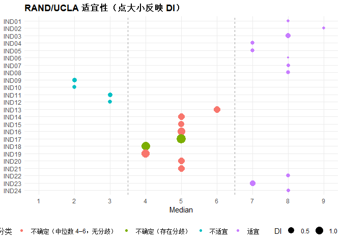

```r
plot_rand_panel(s1)
```

点的大小反映 DI。落在 7 右侧但仍可能被标成不确定——那就是分歧条目。

# 7. 受控反馈：RAM 的个性化表单

会议前每位专家拿到自己的表：直方图/分布、本人原分、Median。

```r
fb <- prepare_feedback(rand_ucla_demo, round = 1)
fb[fb$expert_id == "P1",
   c("item_id", "own_score", "median", "di", "class_zh", "anonymous_comments")]
```

```
#>    item_id own_score median         di                     class_zh
#> 1    IND01         8      8 0.08219178                         适宜
#> 2    IND02         8      9 0.07594937                         适宜
#> 3    IND03         6      8 0.36065574                         适宜
#> 4    IND04         3      7 0.16393443                         适宜
#> 5    IND05         7      7 0.16393443                         适宜
#> 6    IND06         8      8 0.00000000                         适宜
#> 7    IND07         7      8 0.13157895                         适宜
#> 8    IND08         5      8 0.16393443                         适宜
#> 9    IND09         4      2 0.24427481                       不适宜
#> 10   IND10         5      2 0.17518248                       不适宜
#> 11   IND11         4      3 0.28318584                       不适宜
#> 12   IND12         1      3 0.16393443                       不适宜
#> 13   IND13         4      6 0.60377358 不确定（中位数 4–6，无分歧）
#> 14   IND14         6      5 0.60377358 不确定（中位数 4–6，无分歧）
#> 15   IND15         6      5 0.51063830 不确定（中位数 4–6，无分歧）
#> 16   IND16         7      5 0.92857143 不确定（中位数 4–6，无分歧）
#> 17   IND17         9      5 1.50000000           不确定（存在分歧）
#> 18   IND18         8      4 1.35483871           不确定（存在分歧）
#> 19   IND19         4      4 1.03896104 不确定（中位数 4–6，无分歧）
#> 20   IND20         5      5 0.64285714 不确定（中位数 4–6，无分歧）
#> 21   IND21         1      5 0.70967742 不确定（中位数 4–6，无分歧）
#> 22   IND22         8      8 0.17518248                         适宜
#> 23   IND23         8      7 0.37383178                         适宜
#> 24   IND24         8      8 0.13157895                         适宜
#>    anonymous_comments
#> 1
#> 2
#> 3
#> 4
#> 5
#> 6
#> 7
#> 8
#> 9
#> 10
#> 11
#> 12
#> 13
#> 14
#> 15
#> 16
#> 17
#> 18
#> 19
#> 20
#> 21
#> 22
#> 23
#> 24
```

**解读：** 讨论由有经验的主持人聚焦分歧指征。讨论后**再次独立评分**，不是举手表决出一个集体分数。匿名在讨论会中往往只能做到“发言可被识别、评分仍不具名”。

# 8. 第 2 轮：最终适宜性

```r
res <- analyze_delphi(rand_ucla_demo)
res
```

```
#> Delphi 分析结果
#>   场景: RAND/UCLA 适宜性评价
#>   题目: 稳定型冠心病血运重建适宜性评价（模拟 RAND/UCLA 面板）
#>   轮次: 1, 2
#>   参与度:
#>     第 1 轮  9/9  (100.0%)
#>     第 2 轮  8/9  (88.9%)
#>   末轮分类:
#>     不确定（中位数 4–6，无分歧）: 4
#>     不确定（存在分歧）: 1
#>     不适宜: 6
#>     适宜: 13
#>   稳定性建议终止: 否
```

```r
last <- res$last_classification
last[, c("item_id", "median_iqr", "di", "disagreement", "class_zh", "evidence_level")]
```

```
#>    item_id median_iqr        di disagreement                     class_zh
#> 25   IND01    9 (8–9) 0.1172638        FALSE                         适宜
#> 26   IND02    8 (8–9) 0.1196013        FALSE                         适宜
#> 27   IND03    9 (8–9) 0.1172638        FALSE                         适宜
#> 28   IND04    8 (6–9) 0.4590164        FALSE                         适宜
#> 29   IND05    9 (8–9) 0.1172638        FALSE                         适宜
#> 30   IND06    8 (7–8) 0.1457490        FALSE                         适宜
#> 31   IND07    8 (7–9) 0.2627737        FALSE                         适宜
#> 32   IND08    8 (7–8) 0.1639344        FALSE                         适宜
#> 33   IND09    2 (1–3) 0.2627737        FALSE                       不适宜
#> 34   IND10    2 (2–3) 0.1639344        FALSE                       不适宜
#> 35   IND11    2 (2–2) 0.0000000        FALSE                       不适宜
#> 36   IND12    2 (1–2) 0.1315789        FALSE                       不适宜
#> 37   IND13    3 (3–4) 0.1925134        FALSE                       不适宜
#> 38   IND14    5 (4–5) 0.0000000        FALSE 不确定（中位数 4–6，无分歧）
```

[output cut: 35 more lines]

**解读最终三类：**

- **适宜：** 可以进入后续“该做”清单；若研究设计含 Necessity，只对这些指征再评“不做是否不可接受”。
- **不适宜：** 预期伤害大于获益；质量改进中常作为减少过度使用的靶点。
- **不确定：** 可能是证据不足，也可能是真实学派分歧。正确写法是“本面板在该指征上不确定”，而不是继续投到出现 80%。

对照两套分歧：

```r
last[, c("item_id", "classic_disagreement", "ipras_disagreement", "di", "class_zh")]
```

```
#>    item_id classic_disagreement ipras_disagreement        di
#> 25   IND01                FALSE              FALSE 0.1172638
#> 26   IND02                FALSE              FALSE 0.1196013
#> 27   IND03                FALSE              FALSE 0.1172638
#> 28   IND04                FALSE              FALSE 0.4590164
#> 29   IND05                FALSE              FALSE 0.1172638
#> 30   IND06                FALSE              FALSE 0.1457490
#> 31   IND07                FALSE              FALSE 0.2627737
#> 32   IND08                FALSE              FALSE 0.1639344
#> 33   IND09                FALSE              FALSE 0.2627737
#> 34   IND10                FALSE              FALSE 0.1639344
#> 35   IND11                FALSE              FALSE 0.0000000
#> 36   IND12                FALSE              FALSE 0.1315789
#> 37   IND13                FALSE              FALSE 0.1925134
#> 38   IND14                FALSE              FALSE 0.0000000
```

[output cut: 35 more lines]

# 9. 稳定性：RAM 允许改变，但不追求全员一致

```r
res$stability[, c("item_id", "median_r1", "median_r2", "class_r1", "class_r2",
                  "class_unchanged")]
```

```
#>    item_id median_r1 median_r2      class_r1      class_r2 class_unchanged
#> 1    IND01         8       9.0   appropriate   appropriate            TRUE
#> 2    IND02         9       8.0   appropriate   appropriate            TRUE
#> 3    IND03         8       9.0   appropriate   appropriate            TRUE
#> 4    IND04         7       7.5   appropriate   appropriate            TRUE
#> 5    IND05         7       9.0   appropriate   appropriate            TRUE
#> 6    IND06         8       8.0   appropriate   appropriate            TRUE
#> 7    IND07         8       8.0   appropriate   appropriate            TRUE
#> 8    IND08         8       7.5   appropriate   appropriate            TRUE
#> 9    IND09         2       2.0 inappropriate inappropriate            TRUE
#> 10   IND10         2       2.5 inappropriate inappropriate            TRUE
#> 11   IND11         3       2.0 inappropriate inappropriate            TRUE
#> 12   IND12         3       1.5 inappropriate inappropriate            TRUE
#> 13   IND13         6       3.0     uncertain inappropriate           FALSE
#> 14   IND14         5       5.0     uncertain     uncertain            TRUE
#> 15   IND15         5       5.5     uncertain     uncertain            TRUE
#> 16   IND16         5       4.0     uncertain     uncertain            TRUE
#> 17   IND17         5       2.0     uncertain inappropriate           FALSE
#> 18   IND18         4       7.0     uncertain   appropriate           FALSE
#> 19   IND19         4       4.0     uncertain     uncertain            TRUE
#> 20   IND20         5       7.0     uncertain   appropriate           FALSE
#> 21   IND21         5       6.0     uncertain     uncertain            TRUE
#> 22   IND22         8       9.0   appropriate   appropriate            TRUE
#> 23   IND23         7       8.0   appropriate   appropriate            TRUE
#> 24   IND24         8       8.5   appropriate   appropriate            TRUE
```

```r
res$stopping
```

```
#> $recommend_stop
#> [1] FALSE
#>
#> $class_unchanged_pct
#> [1] 0.8333333
#>
#> $median_stable_pct
#> [1] 0.75
#>
#> $p_high_stable_pct
#> [1] 0.5
#>
#> $max_rounds
#> [1] 2
#>
#> $current_round
#> [1] 2
#>
#> $note
#> [1] "Wilcoxon P>0.05 不能单独定义为意见稳定，因为 P 值依赖样本量。"
```

**解读：** 若干指征从 Uncertain 转为 Appropriate，通常是误解被讨论澄清。若 DI 仍然 ≥1，应保留 Uncertain。Policy Delphi / RAM 都承认：**没有共识本身就是结果。**

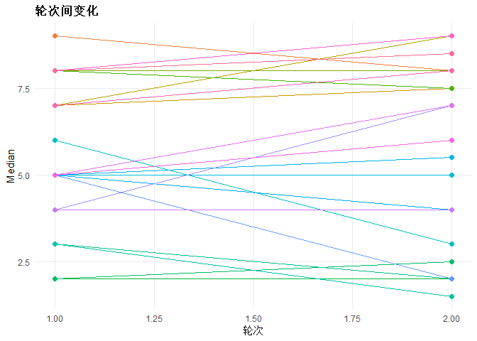

```r
plot_round_shift(res, metric = "median")
```

# 10. 证据列与适宜性列必须分开

```r
last[, c("item_id", "evidence_level", "median", "di", "class_zh")]
```

```
#>    item_id evidence_level median        di                     class_zh
#> 25   IND01              A    9.0 0.1172638                         适宜
#> 26   IND02              A    8.0 0.1196013                         适宜
#> 27   IND03              A    9.0 0.1172638                         适宜
#> 28   IND04              C    7.5 0.4590164                         适宜
#> 29   IND05              B    9.0 0.1172638                         适宜
#> 30   IND06              B    8.0 0.1457490                         适宜
#> 31   IND07              C    8.0 0.2627737                         适宜
#> 32   IND08              C    7.5 0.1639344                         适宜
#> 33   IND09              A    2.0 0.2627737                       不适宜
#> 34   IND10              A    2.5 0.1639344                       不适宜
#> 35   IND11              C    2.0 0.0000000                       不适宜
#> 36   IND12              C    1.5 0.1315789                       不适宜
#> 37   IND13              B    3.0 0.1925134                       不适宜
#> 38   IND14              C    5.0 0.0000000 不确定（中位数 4–6，无分歧）
#> 39   IND15              C    5.5 0.3225806 不确定（中位数 4–6，无分歧）
#> 40   IND16              A    4.0 0.7200000 不确定（中位数 4–6，无分歧）
#> 41   IND17              A    2.0 0.1457490                       不适宜
#> 42   IND18              B    7.0 0.5775401                         适宜
#> 43   IND19              C    4.0 1.5433071           不确定（存在分歧）
#> 44   IND20              B    7.0 0.1493776                         适宜
#> 45   IND21              B    6.0 0.2834646 不确定（中位数 4–6，无分歧）
#> 46   IND22              A    9.0 0.0000000                         适宜
#> 47   IND23              B    8.0 0.1196013                         适宜
#> 48   IND24              B    8.5 0.1315789                         适宜
```

证据等级 C 的指征仍可能被评为适宜（专家判断补证据缺口）；证据等级 A 仍可能不确定（获益伤害权衡有争议）。RAM 明确把文献综述和面板判断分成两步。

# 11. 定性意见

```r
summarize_comments(study = rand_ucla_demo)$by_theme
```

```
#> [1] theme n
#> <0 rows> (or 0-length row.names)
```

# 12. 报告

```r
html <- delphi_report(res, file = tempfile(fileext = ".html"), template = "rand_ucla")
file.exists(html)
```

```
#> [1] TRUE
```

```r
accord_checklist(res)[accord_checklist(res)$id %in% c("T1", "M9", "M11", "M14", "R3"),
                      c("id", "item", "status")]
```

```
#>     id                                                               item
#> 1   T1 在题目中标明这是共识研究，并说明所用方法（如 Delphi、RAND/UCLA）。
#> 13  M9                                 收集意见并形成共识的具体方法步骤。
#> 15 M11                                                   共识的预先定义。
#> 18 M14                                           轮次之间的受控反馈内容。
#> 28  R3                                                     各轮定量结果。
#>    status
#> 1     Yes
#> 13    Yes
#> 15    Yes
#> 18    Yes
#> 28    Yes
```

写 RAM 论文时，题目就应写明 RAND/UCLA 或 appropriateness panel。ACCORD 的 M9 专门点名可报告 Delphi / RAND-UCLA / 名义群体法。

# 13. 本场景常见错误

1. 用 40 人开放 Delphi 的 75% 规则套在 RAM 上；
2. 只看 Median，忽略分歧，把两极条目写成“适宜”；
3. 开会举手“统一意见”，破坏独立复评；
4. 把 Uncertain 当成失败，反复投到出现共识；
5. 面板全是实施该操作的专科医生，缺少全科或相邻学科；
6. 第 1 轮前不提供证据综述；
7. 指征过于笼统，无法对应真实患者；
8. 用 Kendall W 或 Cr 代替 DI。

# 14. 换成自己的指征数据

```r
study <- delphi_study(
  preset_protocol("rand_ucla"),
  panel = your_panel,   # 建议 7–15 人
  items = your_indications,
  ratings = your_ratings,
  meta = list(
    title = "……适宜性评价",
    objective = "判断何种指征下实施……是否适宜",
    evidence_note = "会前系统综述摘要……"
  )
)
analyze_delphi(study) |> delphi_report(file = "ram-report.html")
```

相关教程：`vignette("clinical-consensus", package = "delphir")`；核心结局集见 `vignette("comet-cos", package = "delphir")`。